# The Politics of Corruption

Lecture 9: Machines — Clientelism, Patronage, and Vote Buying

Bogdan G. Popescu

bgpopescu@tec.mx

Tecnológico de Monterrey

## Three questions about that picture

1. Why flour and oil, and not cash?
2. **On Sunday nobody can see your ballot. So why does any of this work?**
3. He asks the household to **turn up**, not to vote a particular way. Why might that be easier to hold them to?

The second one is the question the hour is built to answer. We will find **three different answers** to it.

## Today

**By the end, you should be able to:**

- Tell apart programmatic politics, patronage, vote buying, turnout buying and clientelist service
- Say which of those are clientelist, and what an ongoing clientelist *relationship* adds
- Explain how a machine can tell whether you complied, though the ballot is secret (Stokes)
- Explain why buying **turnout** sidesteps that problem (Nichter)
- Explain how reciprocity enforces the bargain with nobody watching (Finan & Schechter)

## This is not rare

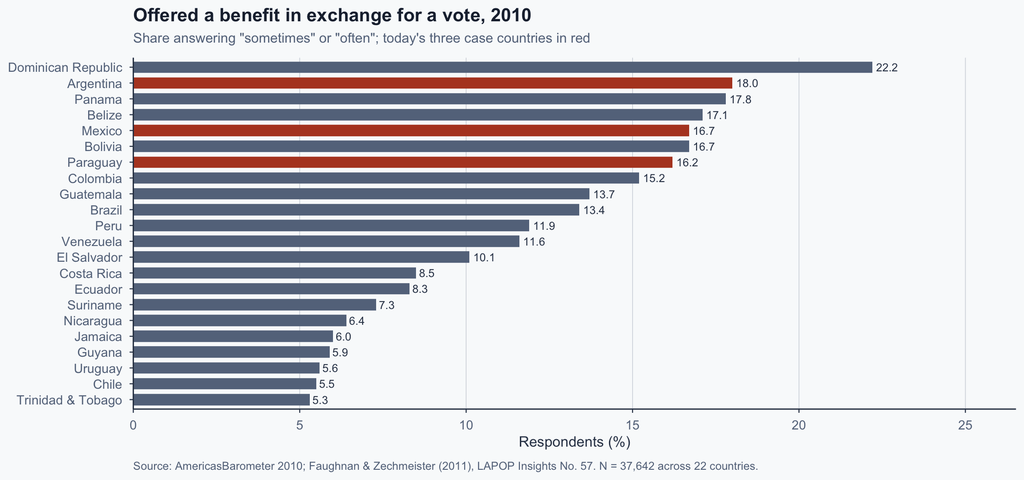

## Asked directly, almost nobody admits it

A **list experiment** asks how many items on a list apply to you, never which ones. Nobody has to admit anything.

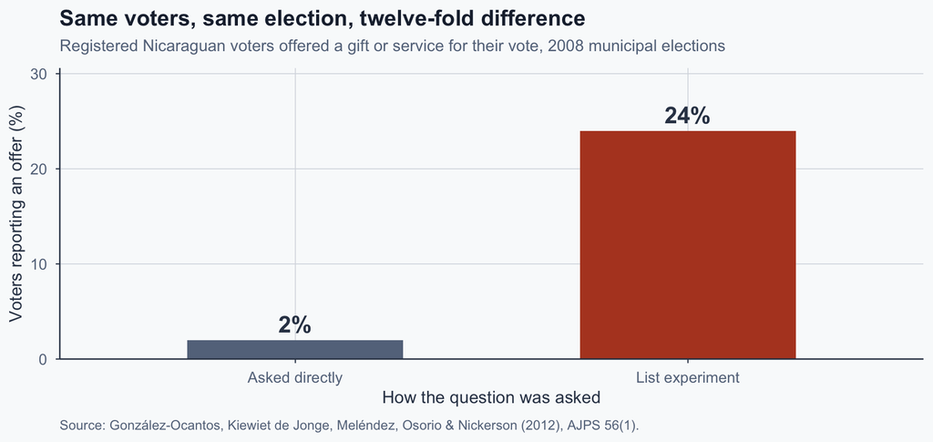

## Two ways to ask the same question

**Asked directly**

> “Did a party worker offer you a gift or a service in exchange for your vote?”

You have to say it about yourself, out loud, to a stranger with a clipboard.

**2% said yes.**

**The list experiment**

Everyone is asked the same thing: *how many of these happened to you?* — **the number only, never which.**

Half the sample gets three harmless items:

- a poster went up on your house
- you went to a campaign rally
- a candidate came to your door

The other half gets those three, **plus one**:

- someone offered you a gift or a service for your vote

Nobody admits anything. The second group’s average just runs **0.24 items higher**, and that gap is the 24%.

Author’s illustration of the method; the three harmless items are invented. The Nicaraguan result is from González-Ocantos et al. (2012).

# I. What Exchange Are We Talking About?

Thomas Nast, “The Tammany Tiger Loose,” *Harper’s Weekly*, 1871 — the New York machine as a beast in the arena. Public domain, via [Wikimedia Commons](https://commons.wikimedia.org/wiki/File:Nast-Tammany.jpg).

## Two logics of winning votes

```
%%{init: {"theme":"base","width":1150,"height":620,"htmlLabels":false,"flowchart":{"useMaxWidth":true,"htmlLabels":false,"nodeSpacing":70,"rankSpacing":130,"padding":18,"curve":"basis"},"themeVariables":{"fontSize":"22px","fontFamily":"DM Sans, Segoe UI, sans-serif","primaryColor":"#e6ecf2","primary…
flowchart LR
  P["Party wants<br/>your vote"] --> A["PROGRAMMATIC<br/>promise a rule"]
  P --> B["CLIENTELIST<br/>hand over a thing"]
  A --> A2["A pension for<br/>everyone over 65"] --> A3["You get it<br/>either way"]
  B --> B2["A food parcel<br/>for you, this week"] --> B3["Only if<br/>you comply"]

  classDef prog fill:#dcebe4,stroke:#4a7c6f,stroke-width:2.5px,color:#1e293b;
  classDef clie fill:#f7e2da,stroke:#b44527,stroke-width:2.5px,color:#1e293b;
  classDef root fill:#e6ecf2,stroke:#334155,stroke-width:2.5px,color:#1e293b;
  class A,A2,A3 prog; class B,B2,B3 clie; class P root;
```

Author’s illustration, following Hicken (2011).

## Hicken’s four elements

A relationship is **clientelist** when all four hold:

1. **Dyadic** — a two-sided relationship between specific people
2. **Contingent** — you get it only if you deliver political support, and lose it if you stop
3. **Hierarchical** — the side handing out the benefit holds much more power
4. **Iterated** — it repeats; both sides expect a next time

**Keep these straight.**

- **Clientelism** proper is the ongoing relationship: all four elements, iterated included.
- **Clientelist strategies** are the wider family of targeted, contingent exchanges. Vote buying and turnout buying belong here even when they happen once.
- **Patron** and **client** are just the two sides. Not the same as **patronage**, which here means public jobs for party workers.
- Scholars draw the line differently — Finan and Schechter use “vote buying” broadly, for the whole family.

Source: Hicken (2011, pp. 291–293); definitional note from Finan & Schechter (2012, p. 1, n. 4).

## Two questions, four cells

Two questions: **Who gets the benefit? Does political support determine whether they get it?**

|  | **You get it regardless of political support** | **You get it only if you support me** |
| --- | --- | --- |
| **Broad group / everyone who qualifies** | National pension | Rare, hard to sustain |
| **Selected people or groups** | Pork; one-off gift | **Clientelist exchange** |

Clientelist strategies occupy this cell: **particularistic *and* contingent**. An ongoing clientelist *relationship* adds hierarchy and iteration.

Author’s illustration, adapted from Hicken (2011).

## Programmatic politics

**A benefit promised to an entire category of citizens, written into a rule.**

- **Who receives:** anyone who qualifies — here, everyone over 65
- **What is exchanged:** a policy, not a thing
- **The test:** you get it whether or not you voted for them

**Isn’t this just campaigning?** Yes — all four of these are campaigning. The difference is how the benefit is delivered. Here the politician promises a general policy: if the pension becomes law, everyone who qualifies receives it, whether they supported him or not. In the next three cases, the benefit is tied more directly to what you do politically.

Following Hicken (2011).

## Patronage

**A public job given to a party worker as payment for service to the party.**

- **Who receives:** party insiders, not voters at large
- **What is exchanged:** the post itself — Diego paid in work he did for the party
- **The test:** the currency is public office employment, and the recipient worked for the party

Following Hicken (2011). Diego’s case is Session 6.

## ▶ Mexico — Ayala, Morelos

[video not shown]

1. What is handed over here, and what is asked for in return?  
2. Thirty employees were fired. How did anyone know whom to fire?  
3. The party worker is not the candidate. What is his job here, and what happens to him if he fails?  
4. The clip says a third of voters were approached. Our first chart said 16.7% for Mexico. Why might the two differ?

France 24 English — Ayala, Morelos. Plays 0:00-1:52.

## ▶ Mexico — worked

1. **What is handed over, and what is asked in return?**  
   Groceries and buckets now, for a vote. The solar heaters go only to those who complied — conditional, and it comes back next time.
2. **How did anyone know whom to fire?**  
   They asked them to their faces and people answered out loud. Nobody read a ballot. Hold on to that.
3. **What is the party worker’s job, and what if he fails?**  
   He is the middleman: he hands out the goods and reports back. His own public job is the hostage.
4. **A third of voters, or 16.7% — why do they differ?**  
   Different years, populations and instruments. The NGO counted incidents citizens reported; the survey asked a sample. Both are floors.

## Vote buying

**A material payment tied to how you vote in a particular election.**

- **Who receives:** ordinary voters, targeted one at a time
- **What is exchanged:** cash, food or goods, once, close to the election
- **The test:** the debt is settled at the ballot box — nothing is carried forward

Real machines do not read our definitions. The Mexican clip holds both: a purchase at the door, inside a relationship that comes back next election.

Following Hicken (2011).

## ▶ Kyrgyzstan — parliamentary election, 4 October 2020

[video not shown]

1. What does the photograph prove?  
2. Why is photographing your own ballot against the rules?  
3. Getting that photo is a lot of work. What could a party do instead that needs no proof at all?

RFE/RL — Kyrgyz parliamentary election, 4 October 2020. Plays 0:24-0:46.

## ▶ Kyrgyzstan — worked

1. **What does the photograph prove?**  
   That you voted the way you were paid to. It turns a promise nobody can check into evidence.
2. **Why is photographing your ballot against the rules?**  
   Because the secret ballot exists to make exactly that proof impossible. The phone defeats the institution.
3. **What could a party do instead, needing no proof?**  
   Hold that one open — you will work it out yourselves in the broker exercise.

## Turnout buying

**A benefit conditional on showing up, not on how you vote.**

- **Who receives:** the party’s own supporters — the ones who might stay home
- **What is exchanged:** a ride, a favour, a small payment
- **The test:** nobody asks which box you ticked, only that you went

Following Nichter (2008).

## Five terms, one example each

Five exchanges, distinguished by recipient and by currency. The last three are all clientelist strategies; only an ongoing relationship meets all four of Hicken’s elements.

| Term | Who receives | What is exchanged | Example |
| --- | --- | --- | --- |
| Programmatic politics | Any qualifying citizen | Policy rules | Universal pension law |
| Patronage | Party insiders | Public jobs, contracts | Payroll posts after victory |
| Vote buying | Ordinary voters | Cash, food, goods | Parcel before election day |
| Turnout buying | Own passive supporters | Cash, transport, favours | A ride to the polls |
| Clientelist service | Neighbourhood residents | Access to the state | Getting your water reconnected |

Author’s illustration, drawing on Hicken (2011) and Nichter (2008).

## The running case: Mexico’s PRI

- Founded 1929; held the presidency without interruption until 2000
- Organised society into sectors: labour (CTM), peasants (CNC), popular (CNOP)
- Benefits — land, jobs, credit, relief — flowed **through** these bodies
- Membership and loyalty were the price of access
- In 2000 the PRI candidate took 36.1%, and lost the presidency

A machine is not a conspiracy. It is an **organisation for distributing things**. We will keep asking of the PRI: *what exactly was it buying?*

Sources: Magaloni (2006); Díaz-Cayeros, Estévez & Magaloni (2016). 2000 vote share reported in Klesner (2001).

## The machine needs a middleman

```
%%{init: {"theme":"base","width":1150,"height":580,"htmlLabels":false,"flowchart":{"useMaxWidth":true,"htmlLabels":false,"nodeSpacing":75,"rankSpacing":140,"padding":18,"curve":"basis"},"themeVariables":{"fontSize":"22px","fontFamily":"DM Sans, Segoe UI, sans-serif","primaryColor":"#e6ecf2","primary…
flowchart LR
  L["Party<br/>leaders"] -->|"resources"| B["Broker<br/>local and long-standing<br/>knows who is loyal<br/>and who is buyable"]
  B -->|"goods and favours"| V["Voters in the<br/>neighbourhood"]
  V -->|"votes and turnout"| L

  classDef party fill:#e6ecf2,stroke:#334155,stroke-width:2.5px,color:#1e293b;
  classDef brok fill:#f7e2da,stroke:#b44527,stroke-width:3px,color:#1e293b;
  classDef vote fill:#dcebe4,stroke:#4a7c6f,stroke-width:2.5px,color:#1e293b;
  class L party; class B brok; class V vote;
```

In PRI-era Mexico the middleman usually sat inside a sectoral organisation — a union local or an *ejido* committee.

Author’s illustration, following Stokes (2005) and Stokes, Dunning, Nazareno & Brusco (2013).

## So what?

- We can now say what clientelism *is*: particularistic and contingent.
- But “contingent” is a promise about something the party cannot see.
- Secret ballots were invented to make vote choice invisible.
- So the definition contains a puzzle it cannot solve alone.

Next: how can a contingent exchange survive a secret ballot?

# II. The Secret Ballot Problem

## What the secret ballot changed

**Before.** Parties printed their own ballots — distinctive paper, visible in the hand.

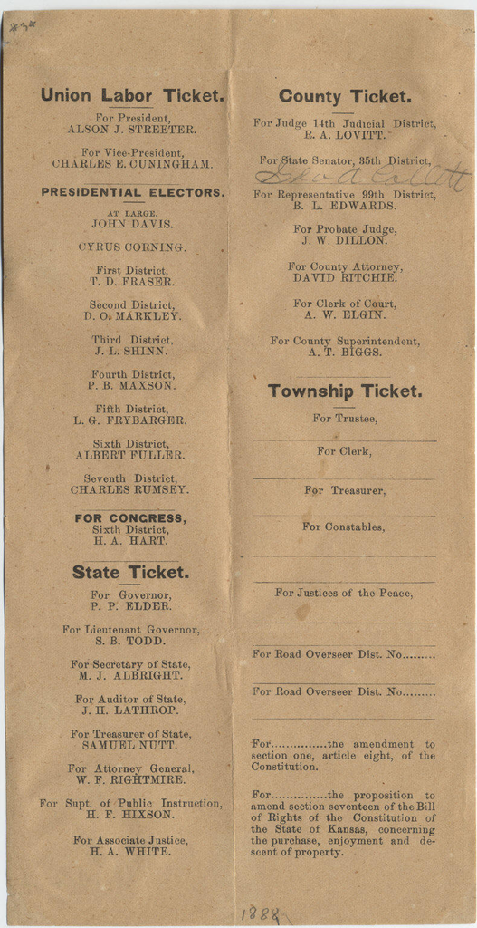

**After.** One official ballot, marked behind a screen: *el voto es secreto*.

[figure not shown]

Massachusetts 1888; Argentina’s Sáenz Peña Law 1912. Compliance stops being visible.

Left: Cornell University Library (1888). Right: ProtoplasmaKid, CC BY-SA 4.0 (2018). Both via Wikimedia Commons; full credits at the end.

## ▶ Brazil — Pernambuco, 2022

[video not shown]

1. The voter is asked whether he voted for the person who paid him. What does he answer?  
2. Candidates hand over cash — but also water, building material, food baskets, even dentures. Why might goods work better than money?  
3. “After the elections they send you away, saying they have already paid for your vote.” Which of our five terms is this?  
4. Whom do candidates approach, and why is the offer harder to refuse in hard times?

## ▶ Brazil — worked

1. **What does the voter answer?**  
   *“I accepted the favor, and then I voted for whoever I wanted.”* He took it and defected — the puzzle on the next slide.
2. **Why might goods work better than money?**  
   They arrive at the house, are worth most to whoever is short, and the clip says candidates offer what is scarce there: water, building material.
3. **Which of our five terms is this?**  
   Vote buying. One payment, one election, no next time — “they have already paid for your vote” says the debt is settled. Clientelism would come back.
4. **Whom do they approach, and why is it harder to refuse in hard times?**  
   People in need. *“Since the person is in need, they take it”* — hardship makes refusing costlier.

## The puzzle in one line

> If the ballot is secret, why pay for a vote you cannot verify?
- The voter can take the food **and** vote as they please.
- Parties spend real money on this across very different electoral systems.
- Either parties are foolish, or we have the mechanism wrong.

## Stokes: accountability, inverted

```
%%{init: {"theme":"base","width":1150,"height":600,"htmlLabels":false,"flowchart":{"useMaxWidth":true,"htmlLabels":false,"nodeSpacing":60,"rankSpacing":110,"padding":16,"curve":"basis"},"themeVariables":{"fontSize":"21px","fontFamily":"DM Sans, Segoe UI, sans-serif","primaryColor":"#e6ecf2","primary…
flowchart LR
  H1["NORMAL"] --> N1["Party acts<br/>in office"] --> N2["Voter judges<br/>the record"] --> N3["Voter punishes<br/>at the ballot box"]
  H2["PERVERSE"] --> P1["Voter acts<br/>in the booth"] --> P2["Party infers<br/>the vote"] --> P3["Party punishes:<br/>goods cut off"]

  classDef norm fill:#dcebe4,stroke:#4a7c6f,stroke-width:2.5px,color:#1e293b;
  classDef perv fill:#f7e2da,stroke:#b44527,stroke-width:2.5px,color:#1e293b;
  classDef lab fill:#1e293b,stroke:#1e293b,stroke-width:2px,color:#f9fafb;
  class N1,N2,N3 norm; class P1,P2,P3 perv; class H1,H2 lab;
```

Author’s illustration of the central claim in Stokes (2005).

## How the threat is sustained

Stokes models machine and voter as a **repeated** game with **imperfect** monitoring.

- It cannot read your ballot, but it reads your street.
- Brokers live where you live: they see rallies, gossip, signals.
- From those signals the machine forms a **guess** about your vote.
- A guess is enough: it only needs to be right often.
- What disciplines you is losing **the flow**, not one parcel.
- The exchange is enforced by the future, not the transaction.

Source: Stokes (2005, pp. 316–320).

## Predictions, and what Argentina showed

#### The model predicts

1. **Poverty.** Poorer voters are cheaper to buy.
2. **Monitoring.** More observable places, more vote buying.
3. **Ideology.** Skip the committed on both sides.

#### The survey data show

1. Poorer respondents far more likely to report targeting.
2. More vote buying in **smaller** communities.
3. Strong Peronists **less** likely to be bought.

Many respondents believed parties could find out how they voted. That belief does the work — true or not.

Sources: Stokes (2005, pp. 318–322); Brusco, Nazareno & Stokes (2004). Cross-nationally, wealth is negatively associated with being targeted across 22 countries (Faughnan & Zechmeister, 2011).

## Exercise — The broker’s list

**In pairs (5 minutes).** You are a broker. You hold **10 food parcels** and a list of **40 households**.

1. Which households get a parcel, and why those?
2. How would you find out whether they kept their side?
3. Now suppose you can find out who turned up to vote, but never how they voted. Would you change your ten?

Be ready to say what information you wished you had.

## So what?

- Stokes solves the puzzle by making monitoring imperfect but real.
- Yet in most places brokers cannot actually observe the ballot.
- And question 3 pointed somewhere else entirely.
- Turnout is often recorded and verifiable. Vote choice is not.

Next: two ways the exchange works **without** watching the ballot.

# III. Turnout, Reciprocity, and Enforcement

A lever voting machine, Old State House, Hartford, Connecticut. Photo by Kenneth C. Zirkel, CC0, via [Wikimedia Commons](https://commons.wikimedia.org/wiki/File:Example_voting_booth.jpg).

## Nichter: buy turnout, not votes

The party stops trying to change minds and pays its **own** supporters to show up.

- They were always going to vote for it. They just might not have gone.
- So nobody needs to see the ballot — only the record of who turned out.
- In many places that record is public, and the broker can simply look.
- The secret ballot stops being an obstacle, because nothing secret is being checked.
- Nichter re-read Stokes’s Argentine data: the rewards went to the party’s own loyalists, not to waverers.

Ask it of our running case: was the PRI buying votes, or buying **turnout**?

Source: Nichter (2008, pp. 19–20, 26–29).

## Who gets targeted? Two theories

Predicted targets under vote buying versus turnout buying.

| Voter type | Likely to vote anyway | Unlikely to vote |
| --- | --- | --- |
| **Strong supporter** | Waste of money | **Nichter: buy turnout** |
| **Weak opponent** | **Stokes: buy the vote** | Two things to change |

- Stokes must monitor **how** you vote; Nichter only **whether**.
- The theories predict opposite targets — so data can adjudicate.

Author’s illustration, after Stokes (2005) and Nichter (2008).

## Finan & Schechter: reciprocity

Rural Paraguay: a household survey after the 2006 municipal elections, plus a survey of the **brokers themselves**.

- 26% of households said a party offered them money, food, or goods.
- Reciprocity was measured years earlier, in an anonymous trust game.
- Anonymous play is a disposition, not a favour to anyone.
- A one-standard-deviation rise in reciprocity raised targeting by **44%**.
- Targeted villagers were **not** closer to the broker in the network.

**Why this answers our puzzle.** The party never has to observe your ballot. If the obligation lives *inside* the voter, nothing external needs enforcing.

Source: Finan & Schechter (2012, pp. 863–864, 869–875).

## But can brokers actually find them?

Brokers’ knowledge of 30 randomly chosen villagers, rural Paraguay.

| What the broker was asked about a villager | Accuracy |
| --- | --- |
| Years of schooling | Correlation 0.73 |
| Name of the spouse | 84% correct |
| Whether the person voted in 2006 | 71% correct (56% by guessing) |
| Which party the person supports | 77–83% correct |

Identical twins report each other’s schooling at 0.87–0.92. Brokers are not far behind.

Source: Finan & Schechter (2012, Table II, pp. 870–872). Twin comparison: Ashenfelter & Krueger (1994), cited therein.

## One parcel, three mechanisms

Why should taking a parcel change what the voter does?

Three accounts of why the same parcel works.

|  | What is bought | What makes you keep your side |
| --- | --- | --- |
| **Stokes** | your **vote** | she may work out how you voted, and cut you off next time |
| **Nichter** | your **turnout** | she can see whether you showed up; your vote stays secret |
| **Finan & Schechter** | your **vote** | you feel you owe her; nobody has to watch at all |

Nichter changes **what is bought**. Finan and Schechter change **who does the enforcing** — you do.

The broker matters in all three, but differently: inferring for Stokes, watching for Nichter, picking the right people for Finan and Schechter.

Author’s illustration, synthesising Stokes (2005), Nichter (2008) and Finan & Schechter (2012).

## Conclusion

We opened with three questions about that picture.

- **Why flour and oil, not cash?** The benefit has to reach a named household and be withheld from everyone else. That is what particularistic and contingent mean.
- **What is the clipboard for?** It is the machine’s answer to the secret ballot — a record of who got what, so compliance can be guessed at and withdrawn.
- **Why ask the household to turn up?** Because turnout can be checked and the vote cannot.

Or nothing is checked at all, and the parcel goes to whoever will feel they owe. Either way, accountability runs backwards: the voter answers to the party.

**Session 12** takes the same broker logic into organised crime, where the good sold is protection.

## References

Ashenfelter, O., & Krueger, A. (1994). Estimates of the economic return to schooling from a new sample of twins. *American Economic Review, 84*(5), 1157–1173.

Brusco, V., Nazareno, M., & Stokes, S. C. (2004). Vote buying in Argentina. *Latin American Research Review, 39*(2), 66–88.

Díaz-Cayeros, A., Estévez, F., & Magaloni, B. (2016). *The political logic of poverty relief: Electoral strategies and social policy in Mexico*. Cambridge University Press.

Faughnan, B. M., & Zechmeister, E. J. (2011). *Vote buying in the Americas* (AmericasBarometer Insights No. 57). Latin American Public Opinion Project, Vanderbilt University.

Finan, F., & Schechter, L. (2012). Vote-buying and reciprocity. *Econometrica, 80*(2), 863–881.

González-Ocantos, E., Kiewiet de Jonge, C., Meléndez, C., Osorio, J., & Nickerson, D. W. (2012). Vote buying and social desirability bias: Experimental evidence from Nicaragua. *American Journal of Political Science, 56*(1), 202–217.

Hicken, A. (2011). Clientelism. *Annual Review of Political Science, 14*, 289–310.

## References (continued)

Klesner, J. L. (2001). The end of Mexico’s one-party regime. *PS: Political Science & Politics, 34*(1), 107–114.

Magaloni, B. (2006). *Voting for autocracy: Hegemonic party survival and its demise in Mexico*. Cambridge University Press.

Nichter, S. (2008). Vote buying or turnout buying? Machine politics and the secret ballot. *American Political Science Review, 102*(1), 19–31.

Stokes, S. C. (2005). Perverse accountability: A formal model of machine politics with evidence from Argentina. *American Political Science Review, 99*(3), 315–325.

Stokes, S. C., Dunning, T., Nazareno, M., & Brusco, V. (2013). *Brokers, voters, and clientelism: The puzzle of distributive politics*. Cambridge University Press.